# Reproducible Research: Peer Assessment 2

# Results

## Across the United States, which types of events (as indicated in the EVTYPE variable) are most harmful with respect to population health?

The top 15 events for fatalities and then for injuries

```r
Fatal <- aggregate(MyStorm$FATALITIES, by = list(MyStorm$EVTYPE), "sum")
names(Fatal) <- c("Event", "Fatalities")
Fatal <- Fatal[order(-Fatal$Fatalities), ][1:15, ]
Fatal
```

```
##                 Event Fatalities
## 130    EXCESSIVE HEAT       1903
## 834           TORNADO       1660
## 153       FLASH FLOOD        978
## 275              HEAT        937
## 464         LIGHTNING        816
## 170             FLOOD        470
## 585       RIP CURRENT        368
## 856         TSTM WIND        255
## 359         HIGH WIND        248
## 19          AVALANCHE        224
## 972      WINTER STORM        206
## 586      RIP CURRENTS        204
## 278         HEAT WAVE        172
## 140      EXTREME COLD        160
## 760 THUNDERSTORM WIND        133
```

```r
Injury <- aggregate(MyStorm$INJURIES, by = list(MyStorm$EVTYPE), "sum")
names(Injury) <- c("Event", "Injuries")
Injury <- Injury[order(-Injury$Injuries), ][1:15, ]
Injury
```

```
##                 Event Injuries
## 834           TORNADO    24633
## 170             FLOOD     6789
## 130    EXCESSIVE HEAT     6525
## 464         LIGHTNING     5230
## 856         TSTM WIND     3954
## 275              HEAT     2100
## 427         ICE STORM     1975
## 153       FLASH FLOOD     1777
## 760 THUNDERSTORM WIND     1488
## 972      WINTER STORM     1321
## 411 HURRICANE/TYPHOON     1275
## 359         HIGH WIND     1137
## 244              HAIL     1068
## 310        HEAVY SNOW     1021
## 957          WILDFIRE      911
```

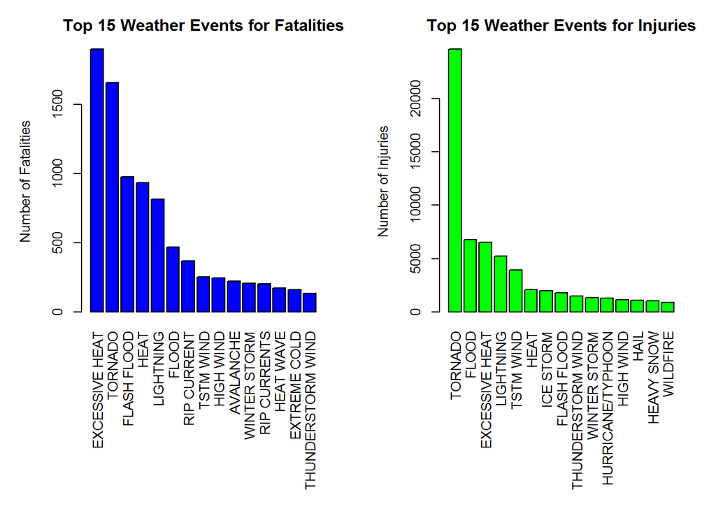

```r
par(mfrow = c(1, 2), mar = c(12, 5, 3, 2), mgp = c(3, 1, 0), cex = 0.8, las = 3)
barplot(Fatal$Fatalities, names.arg = Fatal$Event, col = 'blue',
        main = 'Top 15 Weather Events for Fatalities', ylab = 'Number of Fatalities')
barplot(Injury$Injuries, names.arg = Injury$Event, col = 'green',
        main = 'Top 15 Weather Events for Injuries', ylab = 'Number of Injuries')
```

## Across the United States, which types of events have the greatest economic consequences?

The top 15 events for economic damage were:

```r
Economic <- aggregate(MyStorm$ECONOMIC, by = list(MyStorm$EVTYPE), "sum")
names(Economic) <- c("Event", "Damage")
Economic <- Economic[order(-Economic$Damage), ][1:15, ]
Economic
```

```
##                             Event     Damage
## 842    TORNADOES, TSTM WIND, HAIL 1602500000
## 392               HIGH WINDS/COLD  117500000
## 410     HURRICANE OPAL/HIGH WINDS  110000000
## 973       WINTER STORM HIGH WINDS   65000000
## 295          Heavy Rain/High Surf   15000000
## 441               LAKESHORE FLOOD    7540000
## 389        HIGH WINDS HEAVY RAINS    7510000
## 190                  FOREST FIRES    5500000
## 165          FLASH FLOODING/FLOOD    1925000
## 329 HEAVY SNOW/HIGH WINDS & FLOOD    1520000
## 211                  Frost/Freeze    1100000
## 851         TROPICAL STORM GORDON    1000000
## 118         DUST STORM/HIGH WINDS     550000
## 489      MARINE THUNDERSTORM WIND     486400
## 17          ASTRONOMICAL LOW TIDE     320000
```

[figure not shown]

```r
par(mfrow = c(1, 2), mar = c(5, 4, 4, 2), mgp = c(3, 1, 0), cex = 0.8, las = 3)
barplot(Economic$Damage, width = 2, names.arg = Economic$Event, col = 'blue',
        main = 'Top 15 Weather Events for Ecomonic Damage', ylab = 'Economic Damage')
```

The data shows that a number of events relating to tornados/high wind/hail caused the most economic damage.

# Conclusions

It was found that excessive heat and tornado were the most harmful weather events with respect to population health, while tornadoes/high winds had the greatest economic impact.